# Assignment3

## Assignment 3: Simple Linear Regression and Correlation

In this assignment, you will complete a variety of tasks related to correlation and simple linear regression.

The deliverable for this assignment is a rendered HTML document. Submit your document via Canvas.

For all questions where a comment or an answer is required, be sure to type out the answer. Do not depend on the R code and output to “speak for you”.

**Libraries**: For this assignment, you will need the following libraries: tidyverse, tidymodels, GGally, and lmtest.

Read-in the “airquality” data set (a default R dataset) as a dataframe called “air”. To do this use the code below:

```r
air = airquality
```

Details concerning this dataset can be found here: http://rpubs.com/Nitika/linearRegression_Airquality.

**Question 1** How many rows are in the “air” dataframe?

- Thre are 153 rows or observations.

**Question 2** How many columns are in the “air” dataframe?

- There are 6 columns or variables.

**Question 3** True/False: There is missing data in “Ozone” variable in the dataframe.

- True, there is 37 missing data points in the Ozone variable

```r
str(air)
```

```
'data.frame':   153 obs. of  6 variables:
 $ Ozone  : int  41 36 12 18 NA 28 23 19 8 NA ...
 $ Solar.R: int  190 118 149 313 NA NA 299 99 19 194 ...
 $ Wind   : num  7.4 8 12.6 11.5 14.3 14.9 8.6 13.8 20.1 8.6 ...
 $ Temp   : int  67 72 74 62 56 66 65 59 61 69 ...
 $ Month  : int  5 5 5 5 5 5 5 5 5 5 ...
 $ Day    : int  1 2 3 4 5 6 7 8 9 10 ...
```

```r
summary(air)
```

```
     Ozone           Solar.R           Wind             Temp
 Min.   :  1.00   Min.   :  7.0   Min.   : 1.700   Min.   :56.00
 1st Qu.: 18.00   1st Qu.:115.8   1st Qu.: 7.400   1st Qu.:72.00
 Median : 31.50   Median :205.0   Median : 9.700   Median :79.00
 Mean   : 42.13   Mean   :185.9   Mean   : 9.958   Mean   :77.88
 3rd Qu.: 63.25   3rd Qu.:258.8   3rd Qu.:11.500   3rd Qu.:85.00
 Max.   :168.00   Max.   :334.0   Max.   :20.700   Max.   :97.00
 NA's   :37       NA's   :7
     Month            Day
 Min.   :5.000   Min.   : 1.0
 1st Qu.:6.000   1st Qu.: 8.0
 Median :7.000   Median :16.0
 Mean   :6.993   Mean   :15.8
 3rd Qu.:8.000   3rd Qu.:23.0
 Max.   :9.000   Max.   :31.0
```

**Question 4** Which variable is most likely to be the response (Y) variable?

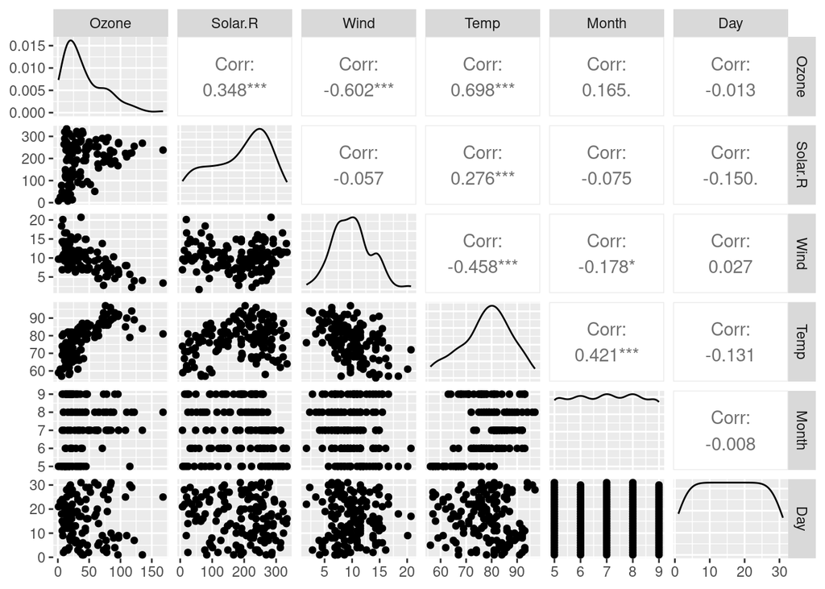

```r
ggpairs(air)
```

A. Ozone  
B. Solar.R  
C. Wind  
D. Temp  
E. Month  
F. Day

- From the ggpairs function Ozone seems to be the response or Y variable.

We have three approaches that we can typically select from to deal with missing data:

1. Delete the rows with missing data
2. Delete the columns with missing data
3. Impute (i.e., estimate or guess) values to replace the missing values

Here we’ll choose to delete rows with any missing data. Use the code below to apply the “drop_na” function to the “air” dataframe. The resulting dataframe will be called “air2”. You will use this dataframe for the remainder of the assignment.

```r
air2 = air %>% drop_na()
```

**Question 5** How many rows remain in this new (air2) data frame?

- There are only 111 rows or observations.

**Question 6** How many columns remain in this new (air2) data frame?

- There are still 6 variables or columns.

Use the “ggpairs” function to develop a visualization of the relationships in this dataset and to show correlation values for the combinations of variables.

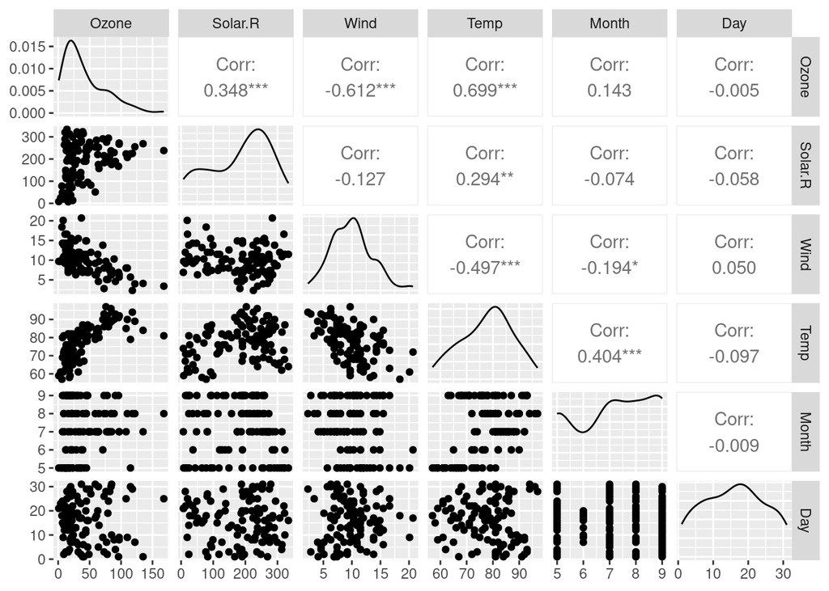

```r
ggpairs(air2)
```

Then use the “ggcorr” function to develop a correlation matrix for the variables. Hint: Use “label = TRUE” in the “ggcorr” function to show the correlation values.

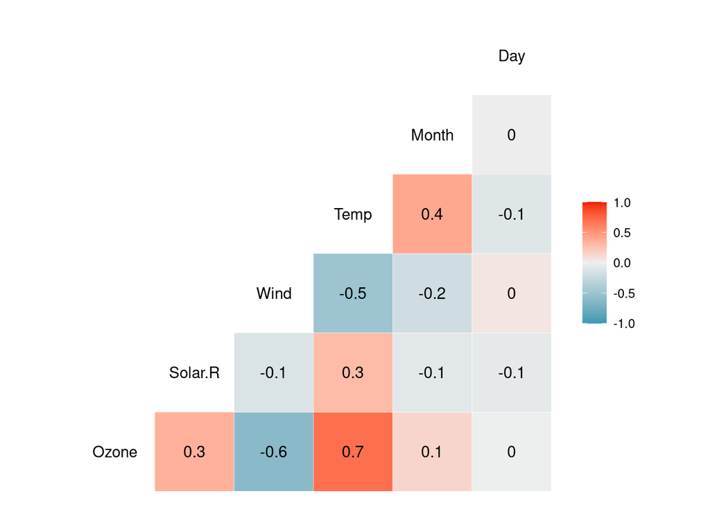

```r
ggcorr(air2, label = TRUE)
```

**Question 7** Which variable is most strongly correlated with the “Ozone” variable?

A. Solar.R  
B. Wind  
**C. Temp**  
D. Month  
E. Day

- Temperature is the variable that is most strongly correlated with Ozone.

**Question 8** Which variable is least strongly correlated with the “Ozone” variable?

A. Solar.R  
B. Wind  
C. Temp  
D. Month  
**E. Day**

- Day is the variable that is least strongly correlated with Ozone.

**Question 9** Plot “Temp” (x axis) versus “Ozone” (y axis) using the “ggplot” function. Choose an appropriate chart type. Which statement best describes the relationship between “Temp” and “Ozone”?

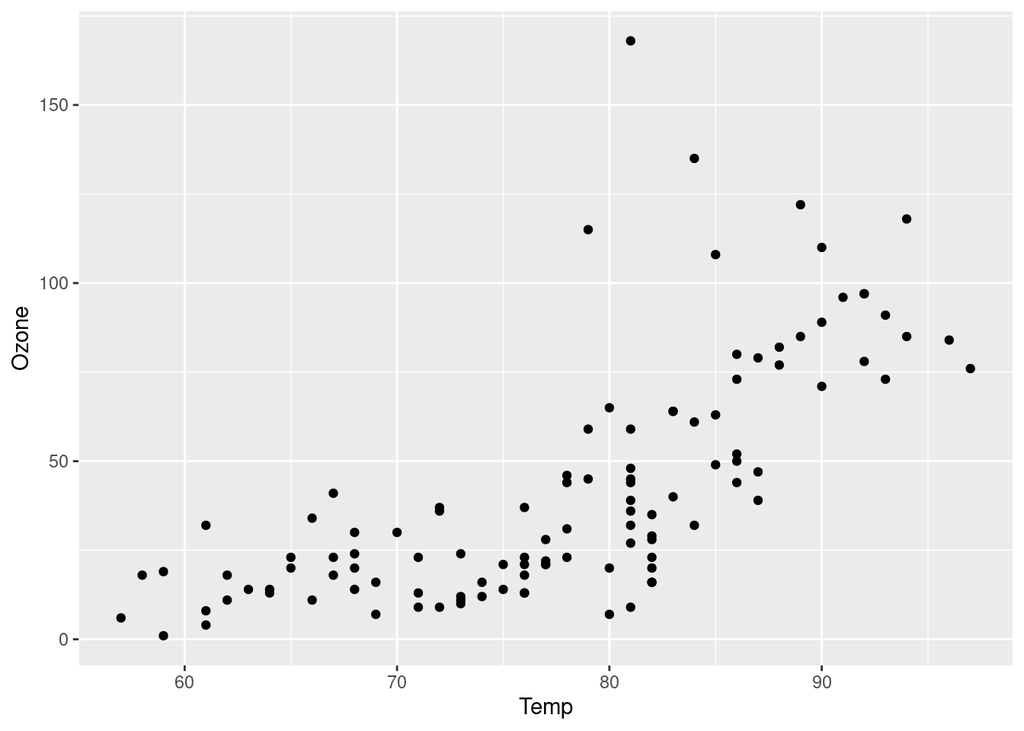

```r
ggplot(air2, aes(x=Temp, y=Ozone))+geom_point()
```

A. As Temp increases, Ozone decreases  
B. As Temp increases there is no noticeable change in Ozone  
**C. As Temp increases, Ozone increases**

- There seems to be a positive relationship so as temperature increases so does ozone.

Create a linear regression model using “Temp” to predict “Ozone”. You must call your model fit “lm_fit”.

```r
lm_fit = lm(Ozone ~ Temp, air2)
summary(lm_fit)
```

```
Call:
lm(formula = Ozone ~ Temp, data = air2)

Residuals:
    Min      1Q  Median      3Q     Max
-40.922 -17.459  -0.874  10.444 118.078

Coefficients:
             Estimate Std. Error t value Pr(>|t|)
(Intercept) -147.6461    18.7553  -7.872 2.76e-12 ***
Temp           2.4391     0.2393  10.192  < 2e-16 ***
---
Signif. codes:  0 '***' 0.001 '**' 0.01 '*' 0.05 '.' 0.1 ' ' 1

Residual standard error: 23.92 on 109 degrees of freedom
Multiple R-squared:  0.488, Adjusted R-squared:  0.4833
F-statistic: 103.9 on 1 and 109 DF,  p-value: < 2.2e-16
```

**Question 10** What is the slope of this regression model (to four decimal places)?

- The slope is 2.4391

**Question 11** what is the R-squared value of this model (not Adjusted R-squared) (to three decimal places)?

- The R-squared value is 0.488

**Question 12** Is the “Temp” variable significant in the model?

- Yes, the temp variable does account for 48.8% of the reason for the change in Ozone so I would say it is a significant variable.

**Question 13** Use the code below to generate 95% confidence intervals for the coefficients. Note that you may need to change “lm_fit” to the name of your model fit if you used a different name.

True/False: A 95% confidence interval for the slope coefficient does not contain zero.

- That statement is true. There slope coefficient does not contain zero.

```r
confint(lm_fit)
```

```
                  2.5 %      97.5 %
(Intercept) -184.818372 -110.473773
Temp           1.964787    2.913433
```

**Question 14**: Using your linear regression model with “Temp” to predict “Ozone”, what is the predicted “Ozone” value when “Temp” is equal to 80 (to two decimal places)?

```r
 -147.6461 + 2.4391*80
```

```
[1] 47.4819
```

- Ozone = -147.6461 + 2.4391*80 = 47.48